# You Should Probably Map That: Introduction to Geospatial Analysis in R

R/Medicine 2026

Anjile An, MPH

Division of Biostatistics  
Department of Population Health Sciences  
Weill Cornell Medicine

May 5, 2026

## Welcome!

## Introductions

Hi! My name is Anjile.

- I’m a Research Biostatistician III at Weill Cornell Medicine
- I work with: Division of Epidemiology faculty and the Meyer Cancer Center, Public Health, Pediatrics, Trauma Surgery, Plastic and Reconstructive Surgery, and CTSC consultations
- Interested in how the built environment and design affects health outcomes
- Avid foodie, crafter, and runner

[figure not shown]

## Why Make Maps?

[figure not shown]

Imago Mundi: Babylonia 500 BCE

- Maps simplify complicated information
- Maps are functional tools - show where resources are, natural features
- Maps give stories context
- Maps are visual!
- And many more

## Data + Maps

Maps can provide a huge amount of insight, like John Snow’s Broad Street Cholera Map (1854):

[figure not shown]

## Data + Maps

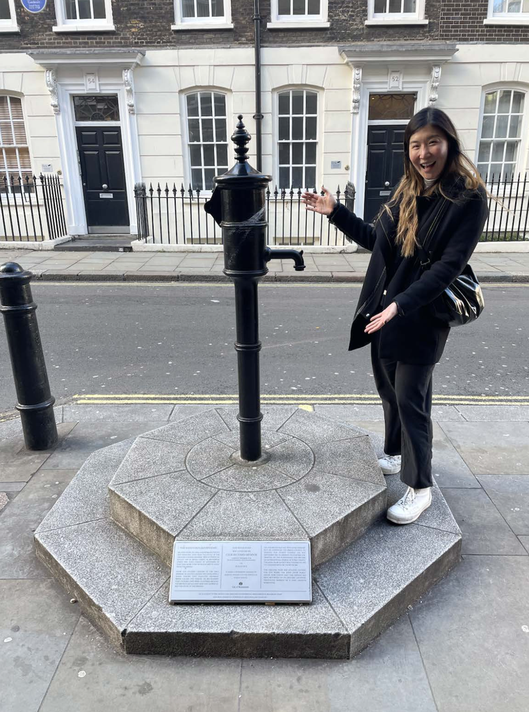

## Data + Maps

Maps with data are particularly powerful! Example: there were ~900 Citibike stations in NYC in 2019.

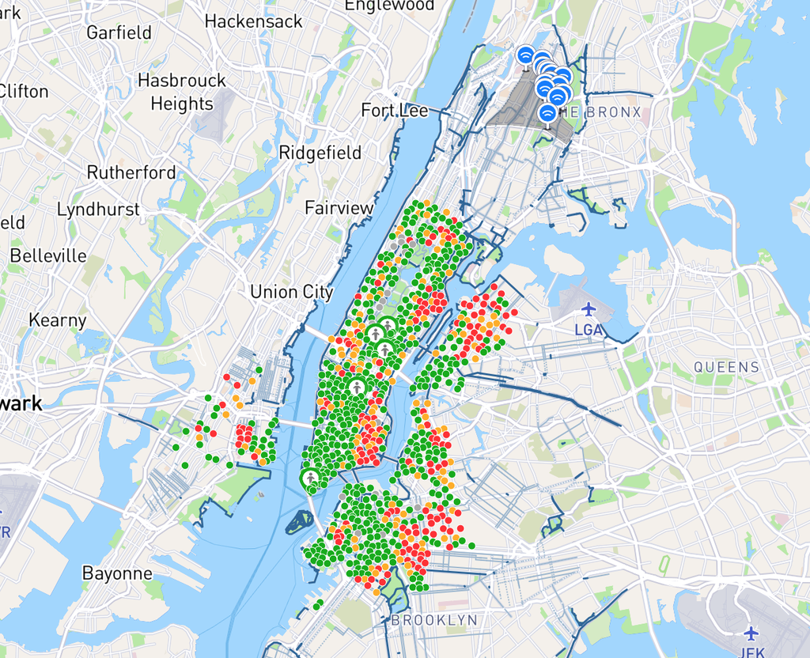

## What is GIS?

A Geographic Information System (GIS) links **locational (spatial)** and **database (tabular)** information and enables users to visualize patterns, relationships, and trends.

This process gives an entirely new perspective to data analysis that can’t be gathered from table or list form.

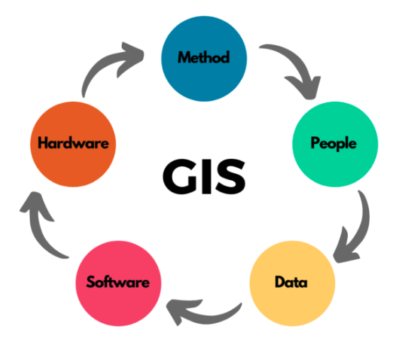

## GIS Specific Software

R is very powerful and can accomplish a lot of geospatial analysis, but there are also lots of things it can’t do (or aren’t meant to do).

Some other software to explore:

- ArcGIS (paid - “gold standard”)
- QGIS (open source version of ArcGIS)
- Google Earth Pro
- GeoDa

## Types of Geospatial Data

There are two main types of geospatial data, vector and raster:

- **Vector data** is very common in social sciences since many features used have discrete boundaries (for example, state or county lines)
- **Raster data** is utilized mostly in environmental sciences (remote sensing data comes in as image, more continuous in nature)

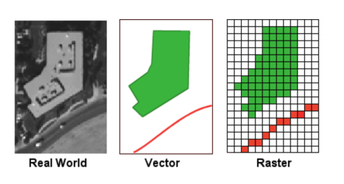

## Layered Model of GIS

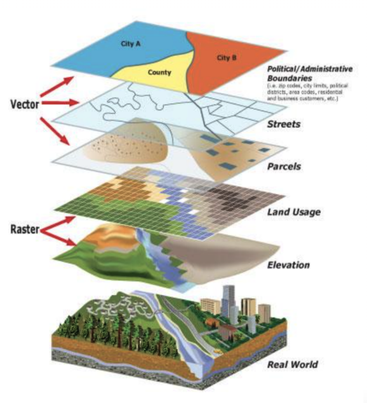

## Types of Maps

There are many different types of maps for all types of purposes:

- **Physical maps** show landscape features like rivers and land masses
- **Topographic maps** show contours of elevation lines
- **Climate maps** show atmospheric conditions
- **Reference or mental maps** show an adjusted version of a map like a “You Are Here” map of the mall, or scaled subway system map
- **Chloropleth maps** shows differences between areas using shading or coloring (heat maps are a version)

## Coordinate Reference System

The Coordinate Reference System (CRS) is why maps showing the same area look distorted - the CRS is crucial as it ties the vector and raster data types together to a location on the earth:

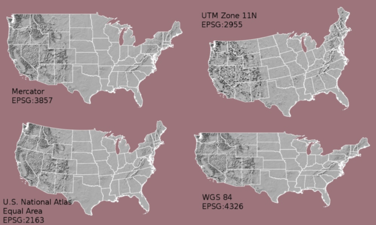

## Geospatial Data Sources

If the map data you want is not available in a package, you can also use **shapefiles** that represents the area. You can find them easily online (NYC OpenData, ERSI, TIGER GIS) as they are the standard for GIS software.

When you download a shapefile, it’ll come as a folder with a bunch of different files - do NOT separate them! `nybb` is the New York borough boundaries, and `nyc_supermarkets` has the locations of supermarkets in the city.

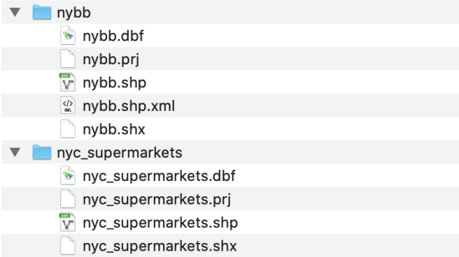

## Package Overview

## `{ggplot2}`

`{ggplot2}` can easily map using **longitude** and **latittude** as x- and y- axes. Syntax is familiar so easy to pick up.

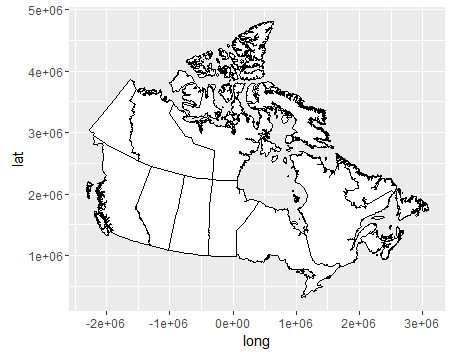

```r
ggplot(data, aes(x = longitude, y = latitude)) +
  geom_polygon()
```

## `{ggplot2}`

There are maps that you can load easily (“county”, “france”, “italy”, “nz”, “state”, “usa”, “world”, or “world2”) using the `map_data()` function:

```r
# load the contiguous US states
us_states <- ggplot2::map_data("state")

head(us_states)
##    long  lat group order  region subregion
## 1 -87.5 30.4     1     1 alabama      <NA>
## 2 -87.5 30.4     1     2 alabama      <NA>
## 3 -87.5 30.4     1     3 alabama      <NA>
## 4 -87.5 30.3     1     4 alabama      <NA>
## 5 -87.6 30.3     1     5 alabama      <NA>
## 6 -87.6 30.3     1     6 alabama      <NA>
```

## `{sf}`

The `{sf}` package provides support for “simple features” - a standardized way to encode spatial vector data.

You can manipulate the class of `sf` objects using `{tidyverse}` functions, and the full list of methods you can use with `sf` objects can be found using the `methods()` call:

```r
methods(class = "sf")
##  [1] [                            [[<-
##  [3] [<-                          $<-
##  [5] aggregate                    as.data.frame
##  [7] cbind                        coerce
##  [9] dbDataType                   dbWriteTable
## [11] duplicated                   filter
## [13] identify                     initialize
## [15] merge                        plot
## [17] points                       print
## [19] rbind                        show
## [21] slotsFromS3                  st_agr
## [23] st_agr<-                     st_area
## [25] st_as_s2                     st_as_sf
## [27] st_as_sfc                    st_bbox
## [29] st_boundary                  st_break_antimeridian
## [31] st_buffer                    st_cast
## [33] st_centroid                  st_collection_extract
## [35] st_concave_hull              st_convex_hull
## [37] st_coordinates               st_crop
## [39] st_crs                       st_crs<-
## [41] st_difference                st_drop_geometry
## [43] st_exterior_ring             st_filter
## [45] st_geometry                  st_geometry<-
## [47] st_inscribed_circle          st_interpolate_aw
## [49] st_intersection              st_intersects
## [51] st_is_full                   st_is_valid
## [53] st_is                        st_join
## [55] st_line_merge                st_m_range
## [57] st_make_valid                st_minimum_bounding_circle
## [59] st_minimum_rotated_rectangle st_nearest_points
## [61] st_node                      st_normalize
## [63] st_point_on_surface          st_polygonize
## [65] st_precision                 st_reverse
## [67] st_sample                    st_segmentize
## [69] st_set_precision             st_shift_longitude
## [71] st_simplify                  st_snap
## [73] st_sym_difference            st_transform
## [75] st_triangulate_constrained   st_triangulate
## [77] st_union                     st_voronoi
## [79] st_wrap_dateline             st_write
## [81] st_z_range                   st_zm
## [83] text                         transform
## see '?methods' for accessing help and source code
```

## `{tmap}`

The `{tmap}` package (thematic maps) resembles `{ggplot2}` syntax, but tailored to maps. You can customize your plots endlessly - change colors, choose color of missing categories, legend position, scale, size, labels etc.

```r
library(tmap)

# basic map
tm_shape(shapefile) +
  tm_polygons()
```